# Market timing: reproducible contribution-penalty comparison

## Protocol

The bundled `inst/extdata/data.csv` contains daily market observations through 2026-02-13. We use the eleven feature columns listed below, without constructing additional predictors. Training windows are 25 calendar years, refit monthly; the evaluation starts in January 2020. Complete training cases are used. The historical training window stays fixed as the cap penalty walks over individual rows in the following month (`walk = 1`).

```r
data <- paper_finance_data()
names(data)
```

```
##  [1] "X"      "target" "S2"     "E2"     "E3"     "P9"     "S1"     "S5"
##  [9] "I2"     "P8"     "P10"    "P12"    "P13"
```

```r
calc_moments(data[,results$feature_cols])
```

```
##    variable         mean   variance excess_kurtosis
## 1        S2  0.025657307 1.04033885      -0.3991072
## 2        E2  0.511900604 2.01244811      -0.1572324
## 3        E3  0.359292676 2.26637711      -0.3171315
## 4        P9  0.390564889 0.14814798      -1.5276043
## 5        S1  0.241765558 1.99940177       1.1263703
## 6        S5  0.032509057 1.27420674      14.5614976
## 7        I2 -0.510398452 1.56964163       1.6594753
## 8        P8  1.546710247 0.49743857       2.8653354
## 9       P10  1.473934814 0.65866273       0.3351919
## 10      P12 -0.008307304 1.21052012      11.0110044
## 11      P13  0.510932030 0.08060118      -1.1134043
```

At each refit, `cv.glmnet` selects `lambda.min` with `alpha = 0.5`, ten random folds, and standardization. Monthly seeds start at 42 and increase by one. This lambda is shared across methods and gamma values. Random inner folds are retained from the original vignette; the outer evaluation remains chronological. This design is not forward-chaining inner validation.

Ceilings use the original helper rule $L_j=7|\mathrm{cor}(X_j,y)|/350$ on the complete training cases. This is a scale-dependent correlation heuristic, not a univariate slope rule. The ordinary `capnet` fit with `gamma = 0` supplies the uncapped model; post-fit capping clips its contributions and retains its intercept. The walk-forward grid is `c(0.1, 1, 10, 100)`.

The data are taken as supplied by the competition. Their proprietary feature release times cannot be independently verified from this file; no portfolio return or investment-risk guarantee is inferred from these forecast results.

```r
# Exact shared definition used by tools/run_paper_experiments.R:
paper_finance
```

```
## function ()
## {
##     rolling_enet(paper_finance_data(), alpha = 0.5, window_years = 25,
##         method = c("capnet_walk", "capnet", "postcap"), eval_start = "2020-01-01")
## }
```

## Forecast scores

`calc_oos_r2` reports one pooled squared-error score, $1-\sum(y_t-\hat y_t)^2/\sum(y_t-\bar y_{t-1})^2$. The benchmark averages preceding **evaluation-period** responses, not initial training responses, and omits the first evaluation observation. This is not an average of monthly R-squared values.

```r
knitr::kable(paper_scores(results,"X"),digits=6)
```

| method | gamma | n | oos_r2 |
| --- | --- | --- | --- |
| Post-Fit Cap | 0.0 | 1538 | 0.005726 |
| Uncapped | 0.0 | 1538 | 0.007055 |
| Walk-forward Capnet | 0.1 | 1538 | 0.007158 |
| Walk-forward Capnet | 1.0 | 1538 | 0.007618 |
| Walk-forward Capnet | 10.0 | 1538 | 0.007623 |
| Walk-forward Capnet | 100.0 | 1538 | 0.007657 |

## Rolling performance and corrected contribution diagnostic

The illustrative walk-forward specification uses gamma 0.1, fixed in this report rather than selected from the plotted evaluation window. Rolling scores use 252 scored observations. Each contribution series is computed as `apply(abs(contribution_matrix), 1, max)` **separately for each model**. Feature columns are selected by name; metadata never enters the maximum.

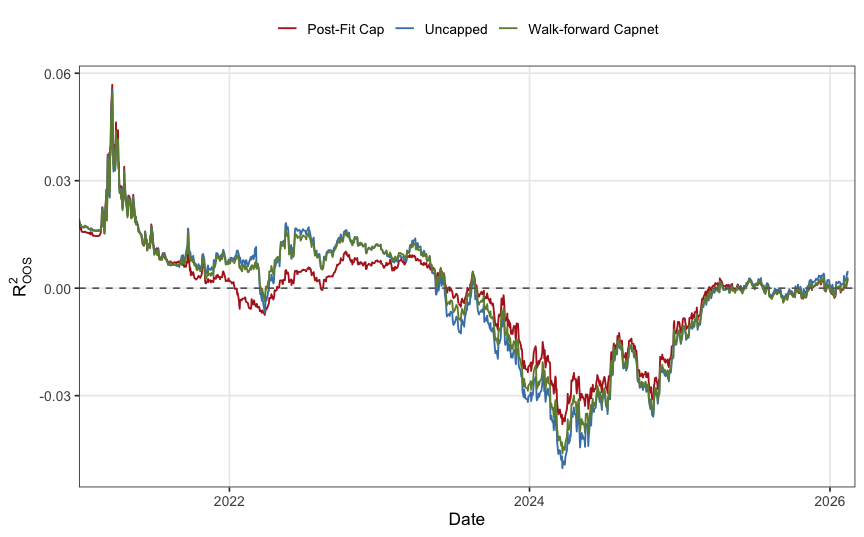

```r
plots <- paper_plots(results,"X",gamma=.1,window=252)
plots$rolling
```

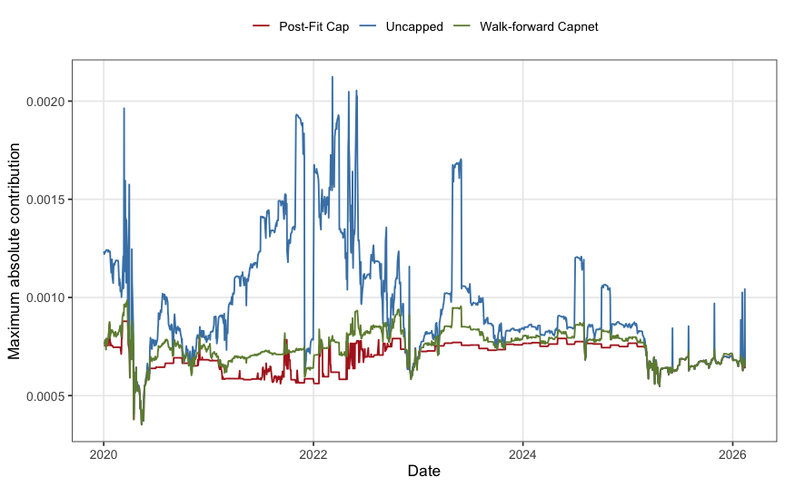

```r
plots$contributions
```

```r
knitr::kable(paper_snapshot(results,"X","2023-05-24",.1,results$feature_cols,1e4),digits=3)
```

| feature | Uncapped | Post-Fit Cap | Walk-forward Capnet |
| --- | --- | --- | --- |
| S2 | -3.439 | -3.439 | -3.362 |
| E2 | -1.395 | -1.118 | -0.663 |
| E3 | 0.000 | 0.000 | 0.000 |
| P9 | 0.124 | 0.124 | 0.079 |
| S1 | -0.156 | -0.156 | -0.028 |
| S5 | 0.073 | 0.073 | 0.073 |
| I2 | -4.863 | -4.863 | -5.249 |
| P8 | -16.074 | -7.707 | -9.443 |
| P10 | 0.000 | 0.000 | -1.054 |
| P12 | 0.743 | 0.743 | 0.897 |
| P13 | -0.640 | -0.640 | -0.677 |

The snapshot scales contributions by $10^4$; the intercept is excluded.

## Numerical diagnostics

```r
stopifnot(all(is.finite(as.numeric(results$predictions$predicted))))
results$diagnostics |> group_by(method,requested_gamma) |>
  summarise(missing=sum(missing),
    reduced_rows=sum(effective_gamma<requested_gamma,na.rm=TRUE),
    unsuccessful_stops=sum(!is.na(convergence)&convergence<0&convergence != -1001),
    .groups="drop")
```

```
## # A tibble: 5 × 5
##   method              requested_gamma missing reduced_rows unsuccessful_stops
##   <chr>                         <dbl>   <int>        <int>              <int>
## 1 Walk-forward Capnet             0.1       0            0                  0
## 2 Walk-forward Capnet             1         0            0                  0
## 3 Walk-forward Capnet            10         0            0                  0
## 4 Walk-forward Capnet           100         0            0                  0
## 5 capnet                          0         0            0                  0
```

## Runtime protocol

Runtime uses three serial repetitions of the entire backtest for each of `glmnet`, `capnet`, and `walk_capnet`, including monthly CV and output assembly. The two contribution-penalized methods both use **gamma 0.1**. The same monthly seeds and lambda-search defaults are used in every repetition. The initial package installation/loading is excluded. Requested BLAS/OpenMP thread limits are one, and no experiment-level parallelism is used for these timings. Reported numbers describe this machine and run, not portable solver rankings.

```r
knitr::kable(read.csv(file.path(results_dir,"runtime-summary.csv")),digits=2)
```

| model | median | min | max | repetitions |
| --- | --- | --- | --- | --- |
| capnet | 24.43 | 23.37 | 39.32 | 3 |
| glmnet | 20.61 | 19.76 | 26.92 | 3 |
| walk_capnet | 81.64 | 76.09 | 89.18 | 3 |

Run `bash tools/reproduce_paper.sh` from the repository root for a fresh source install and all computations. Render this report with `params = list(rerun = TRUE)` to rerun its fitting step independently. Full predictions, convergence diagnostics, package versions, and input/source MD5 checksums are saved in `manuscript/results/finance*` and `runtime*`.